# SCEM Assignment 7

Max Kirwan

17/11/2021

```r
library(tidyverse)
```

## 1. Student’s t-confidence intervals

If the sample mean were higher, the width of the confidence interval would not change.  
However if the sample standard deviation were higher, the width of the confidence interval would increase.  
If the sample size were larger, but the sample mean and sample standard deviation were to stay the same, then the width of the confidence interval would decrease.

```r
library(Stat2Data)
data("Hawks")
RT_weights <- Hawks %>% filter(Species=="RT") %>% select(Weight) %>% na.omit()
RT_weights_vec <- pull(RT_weights)

# Using Student's t-method to compute 99%-level confidence intervals for the population mean
alpha <- 0.01
n <- length(RT_weights_vec)
sample_mean <- mean(RT_weights_vec)
sample_sd <- sd(RT_weights_vec)
t <- qt(1-alpha/2,df=n-1)
lower <- sample_mean-t*sample_sd/sqrt(n)
upper <- sample_mean+t*sample_sd/sqrt(n)
confidence_interval <- c(lower,upper)
confidence_interval
```

```
## [1] 1073.984 1114.877
```

Here we are making the assumption that our data has a Gaussian distribution.  
Let’s check whether this assumption is justified.

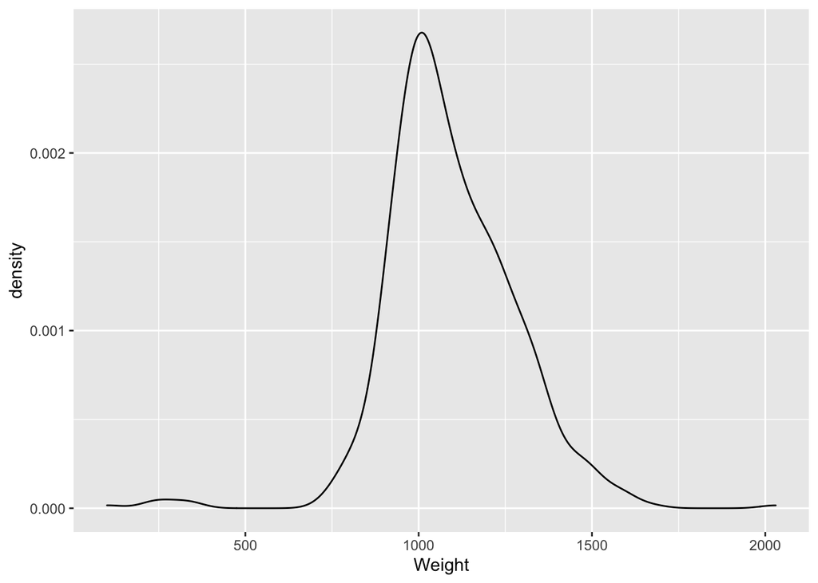

```r
ggplot(data=RT_weights,aes(x=Weight)) + geom_density()
```

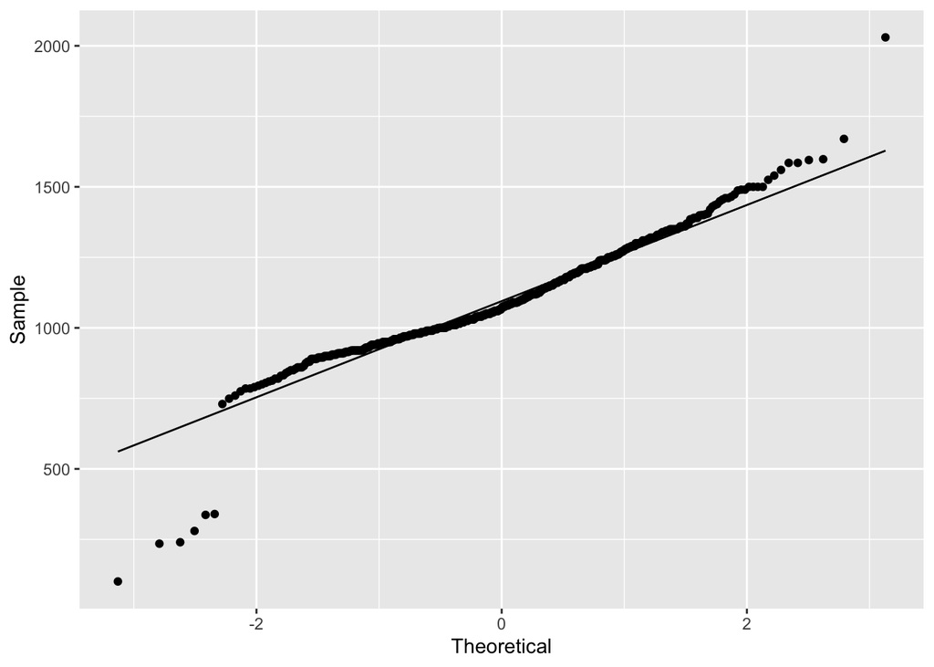

```r
ggplot(data=RT_weights, aes(sample=Weight)) + stat_qq() + stat_qq_line() + labs(x="Theoretical",y="Sample")
```

## 2. One sample t-test

Here we are carrying out a statistical hypothesis test to test the hypothesis that the mean bill length of the Adelie penguins is 40mm.  
Our null hypothesis is $H_0$: $\mu = 40$.  
Our alternative hypothesis is $H_0$: $\mu \ne 40$.  
We choose a significance level of $0.01$.

```r
library(palmerpenguins)
bill_adelie <- penguins %>% filter(species=="Adelie") %>% select(bill_length_mm) %>% na.omit()
bill_adelie_vec <- pull(bill_adelie)

t.test(bill_adelie_vec,mu=40)
```

```
##
##  One Sample t-test
##
## data:  bill_adelie_vec
## t = -5.5762, df = 150, p-value = 1.114e-07
## alternative hypothesis: true mean is not equal to 40
## 95 percent confidence interval:
##  38.36312 39.21966
## sample estimates:
## mean of x
##  38.79139
```

Since the p-value is less than our significance level, $p=0.0000001114 < 0.01 = \alpha$, then we reject the null hypothesis $H_0$ and accept $H_1$: $\mu \ne 40$.

Again, here we are assuming that our data has a Gaussian distribution. Let’s check whether this assumption is justified.

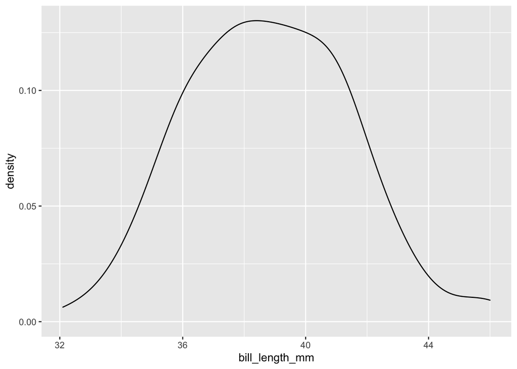

```r
ggplot(data=bill_adelie,aes(x=bill_length_mm)) + geom_density()
```

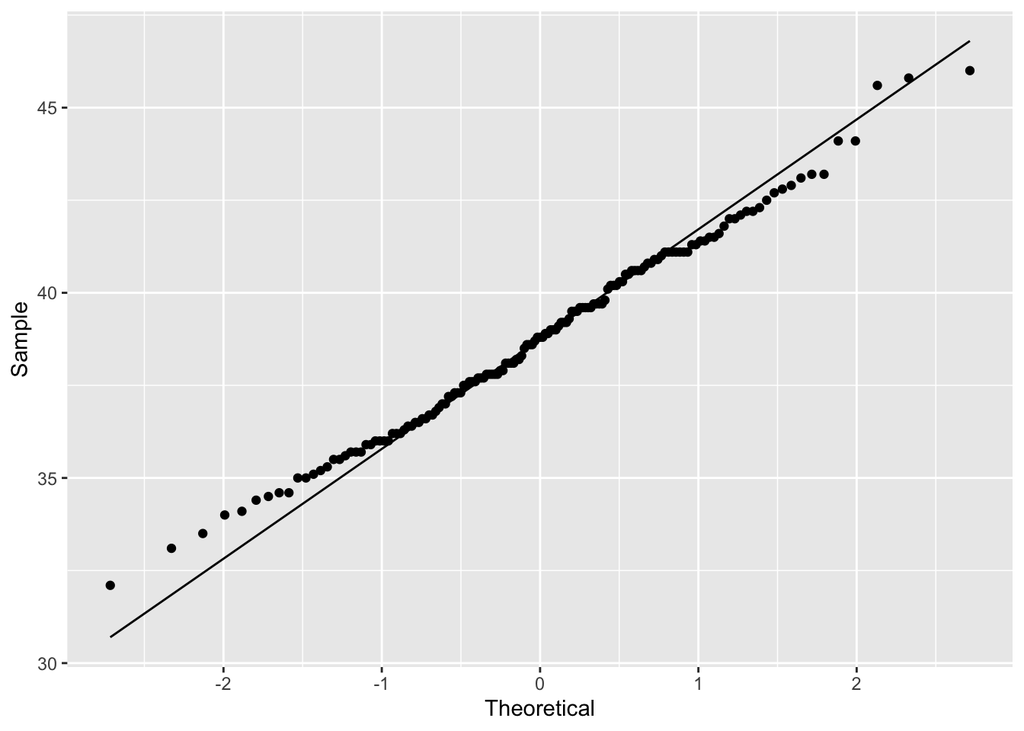

```r
ggplot(data=bill_adelie, aes(sample=bill_length_mm)) + stat_qq() + stat_qq_line() + labs(x="Theoretical",y="Sample")
```

## 3. Implementing a one sample t-test

```r
# Here we are implementing a function which carries out a two-sided one sample t-test
t_test <- function(x,mu_0){
  x <- na.omit(x) # remove any NAs
  n <- length(x)
  sample_mean <- mean(x)
  sample_sd <- sd(x)
  test_statistic <- (sample_mean-mu_0)/(sample_sd/sqrt(n))
  p_value <- 2*(1-pt(abs(test_statistic),df=n-1))
  return(p_value)
}
t_test(bill_adelie_vec,40)
```

```
## [1] 1.114322e-07
```

## 4. The paired t-test

Here we are carrying out a paired t-test to determine whether there is a difference in average yield between the two types of barley.  
Our null hypothesis is $H_0$: $\mu = 0$.  
Our alternative hypothesis is $H_0$: $\mu \ne 0$.  
We choose a significance level of $0.01$.

```r
library(PairedData)
data("Barley")

Barley_diffs <- Barley %>% mutate(diff=Glabron-Velvet)
diffs_vec <- Barley_diffs %>% pull(diff)
t_test(diffs_vec,0) # Using my t test function to calculate p-value
```

```
## [1] 0.01179634
```

```r
t.test(x=Barley$Glabron,y=Barley$Velvet,paired=1) # Using in-built t.test function
```

```
##
##  Paired t-test
##
## data:  Barley$Glabron and Barley$Velvet
## t = 3.0133, df = 11, p-value = 0.0118
## alternative hypothesis: true difference in means is not equal to 0
## 95 percent confidence interval:
##   1.594978 10.238355
## sample estimates:
## mean of the differences
##                5.916667
```

The p-value is greater than our significance level, $p=0.0118 > 0.01 = \alpha$.  
Therefore we accept the null hypothesis $H_0$.

Here we are assuming that the yields of the different types of barley are independent.

```r
# Calculating the effect size using Cohen's d statistic
effect_size <- mean(diffs_vec)/sd(diffs_vec)
effect_size
```

```
## [1] 0.8698615
```

Since the effect size is greater than 0.8 we say that we have a large effect.

## 5. Investigating coverage for Student’s t intervals

```r
student_t_confidence_interval <- function(sample,confidence_level){
  sample <- sample[!is.na(sample)] # remove any missing values
  n <- length(sample) # compute sample size
  mu_est <- mean(sample) # compute sample mean
  sig_est <- sd(sample) # compute sample sd
  alpha <- 1-confidence_level # alpha from gamma
  t <- qt(1-alpha/2,df=n-1) # get student t quantile
  l <- mu_est-(t/sqrt(n))*sig_est # lower
  u <- mu_est+(t/sqrt(n))*sig_est # upper
  return(c(l,u))
}
```

```r
num_trials <- 10000
sample_size <- 30
mu_0 <- 1
sigma_0 <- 3
alpha <- 0.05

set.seed(0) # set random seed for reproducibility
single_alpha_coverage_simulation_df <- crossing(gamma=seq(0.5,0.95,0.05),trial=seq(num_trials)) %>%
  mutate(sample=map(.x=trial,.f=~rnorm(n=sample_size,mean=mu_0,sd=sigma_0))) %>%
  # generate random Gaussian samples
  mutate(ci_interval=map2(.x=gamma,.y=sample,.f=~student_t_confidence_interval(.y,.x))) %>%
  # generate confidence intervals
  mutate(cover=map_lgl(.x=ci_interval,.f=~((min(.x)<=mu_0)&(max(.x)>=mu_0)))) %>%
  # check if interval covers mu_0
  mutate(ci_length=map_dbl(.x=ci_interval, .f=~(max(.x)-min(.x))))
  # compute interval length

cover_means <- single_alpha_coverage_simulation_df %>% group_by(gamma) %>% summarise(mean(cover))
ci_length_means <- single_alpha_coverage_simulation_df %>% group_by(gamma) %>% summarise(ci_length=mean(ci_length))

cover_means
```

```
## # A tibble: 10 × 2
##    gamma `mean(cover)`
##    <dbl>         <dbl>
##  1  0.5          0.500
##  2  0.55         0.548
##  3  0.6          0.596
##  4  0.65         0.650
##  5  0.7          0.707
##  6  0.75         0.751
##  7  0.8          0.797
##  8  0.85         0.850
##  9  0.9          0.897
## 10  0.95         0.950
```

```r
ci_length_means
```

```
## # A tibble: 10 × 2
##    gamma ci_length
##    <dbl>     <dbl>
##  1  0.5      0.741
##  2  0.55     0.831
##  3  0.6      0.929
##  4  0.65     1.03
##  5  0.7      1.15
##  6  0.75     1.27
##  7  0.8      1.42
##  8  0.85     1.60
##  9  0.9      1.84
## 10  0.95     2.22
```

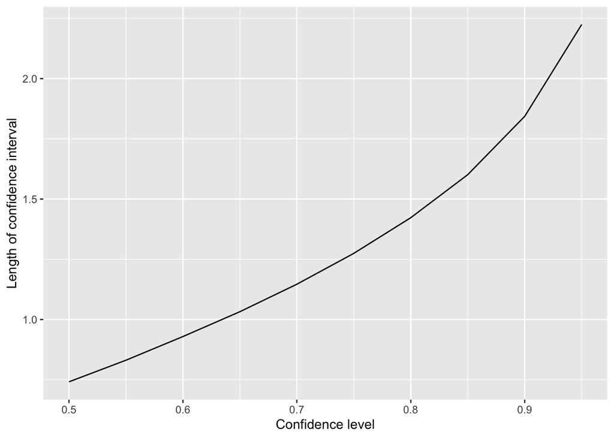

```r
ggplot(ci_length_means,aes(x=gamma,y=ci_length)) + geom_line() + labs(x="Confidence level",y="Length of confidence interval")
```

We can see that as the confidence level increases, the average length of the confidence interval increases.

## 6. Wilson’s confidence interval for proportions

Using Wilson’s method to compute the $99\%$ confidence interval for the pass rate of a driving test.

```r
library(PropCIs)
driving_test_results <- c(1,0,1,0,0,0,0,0,0,1,0,0,0,1,0,1,0,1,0,1,0,0,1,0)
alpha <- 0.01 # failure probability
num_successes <- sum(driving_test_results) # total passes
sample_size <- length(driving_test_results)
scoreci(x=num_successes, n=sample_size, conf.level=1-alpha) # compute Wilson's confidence intervals
```

```
##
##
##
## data:
##
## 99 percent confidence interval:
##  0.1471 0.5918
```

Using Wilson’s method to compute a 95% confidence interval for the proportion of red-tailed hawks who weigh more than a kilogram.

```r
over_1kg <- function(x){
  if(x>1000){return(1)}
  else{return(0)}
}

over_1kg_list <- RT_weights %>% mutate(over_1kg=map_dbl(.x=Weight,.f=~over_1kg(.x))) %>% pull(over_1kg)
print(mean(over_1kg_list))
```

```
## [1] 0.6765734
```

```r
scoreci(x=sum(over_1kg_list), n=length(over_1kg_list), conf.level=0.95)
```

```
##
##
##
## data:
##
## 95 percent confidence interval:
##  0.6372 0.7136
```

## 7. The Binomial test

We shall carry out a statistical hypothesis test to test the hypothesis that $87.5\%$ of the arrivals of flights with the Delta airline at the O’Hare airport are on time.  
Our null hypothesis is $H_0$: $q = 0.875$.  
Our alternative hypothesis is $H_0$: $q \ne 0.875$.  
We choose a significance level of $0.05$.

```r
data("Airlines")
delta_ohare <- Airlines %>% subset(IndOHare==1 & IndDelta==1)
on_time <- pull(delta_ohare,OnTime)
sample_size <- length(on_time)
num_yes <- length(on_time[on_time=="yes"])
alpha <- 0.05

binom.test(x=num_yes, n=sample_size, p=0.875, alternative="two.sided")
```

```
##
##  Exact binomial test
##
## data:  num_yes and sample_size
## number of successes = 527, number of trials = 619, p-value = 0.07796
## alternative hypothesis: true probability of success is not equal to 0.875
## 95 percent confidence interval:
##  0.8208719 0.8784731
## sample estimates:
## probability of success
##              0.8513732
```

Our p-value is greater than our significance level, $p=0.07796 > 0.05 = \alpha$.  
Therefore we accept the null hypothesis, $H_0$: $q = 0.875$.  
To conduct this hypothesis test we have made the assumption that the arrival times of the flights are independent, which in reality is probably not true (a late flight will likely make other flights late).

## 8. Bootstrap confidence intervals

```r
library(boot) # load the library
set.seed(123) # set random seed so that results can be reproduced

# first define a function which computes the mean of a column of interest
compute_mean <- function(df,indicies,col_name){
  sub_sample <- df %>% slice(indicies) %>% pull(all_of(col_name)) # extract subsample
  return(mean(sub_sample,na.rm=1))} # return mean

# use the boot function to generate the bootstrap statistics
results <- boot(data=penguins, statistic=compute_mean, col_name="body_mass_g", R=1000)

# compute the 95%-level confidence interval for the mean
boot.ci(boot.out=results, type="basic", conf=0.95)
```

```
## BOOTSTRAP CONFIDENCE INTERVAL CALCULATIONS
## Based on 1000 bootstrap replicates
##
## CALL :
## boot.ci(boot.out = results, conf = 0.95, type = "basic")
##
## Intervals :
## Level      Basic
## 95%   (4112, 4283 )
## Calculations and Intervals on Original Scale
```

We use a random seed to be able to reproduce our results, as the bootstrap method uses random sampling.

Here we are assuming that our sample is independent and identically distributed, but we do not make any assumptions about the distribution.

```r
set.seed(123) # set random seed so that results can be reproduced

# first define a function which computes the median of a column of interest
compute_median <- function(df,indicies,col_name){
  sub_sample <- df %>% slice(indicies) %>% pull(all_of(col_name)) # extract subsample
  return(median(sub_sample,na.rm=1))} # return median

# use the boot function to generate the bootstrap statistics
results <- boot(data=Hawks, statistic=compute_median, col_name="Weight", R=1000)

# compute the 99%-level confidence interval for the mean
boot.ci(boot.out=results, type="basic", conf=0.99)
```

```
## BOOTSTRAP CONFIDENCE INTERVAL CALCULATIONS
## Based on 1000 bootstrap replicates
##
## CALL :
## boot.ci(boot.out = results, conf = 0.99, type = "basic")
##
## Intervals :
## Level      Basic
## 99%   ( 950, 1000 )
## Calculations and Intervals on Original Scale
## Some basic intervals may be unstable
```

## 10. Effect size for the one sample t-test

```r
effect_size_one_sample_t_test <- function(x,mu){
  sample_mean <- mean(x,na.rm=1)
  sample_sd <- sd(x,na.rm=1)
  return((sample_mean-mu)/sample_sd)
}
effect_size_one_sample_t_test(x=bill_adelie_vec,mu=40)
```

```
## [1] -0.4537835
```

Here we have a moderate effect size for Cohen’s d statistic.